# Exploring Ships in Star Wars

```r
films <- rwars::get_all_films()$results

#get_all_starships doesn't work :/
#the ship ids are also not complete - there are gaps!
#so we'll loop through potential ids and get the ships where they exist
#not very efficient, but ok for a small API

getDataRobust <- function(ids, f) {

   getSingle <- function(id, f) {
     tryCatch(f(id), error = function(e) {
      NULL
     })
   }

   all <- map(ids, ~getSingle(.x, f))
   not_null <- all[!sapply(all, is.null)]

   not_null
}


ids <- 1:100
ships <- getDataRobust(ids, get_starship)
vehicles <- getDataRobust(ids, get_vehicle)

# since we don't want to do this loop every time, lets save the intermediate results
save(films, ships, vehicles, file = "sdata.Rdat")
```

```r
load("sdata.Rdat")
episodes <- tibble(
  title = map_chr(films, "title"),
  episode = map_dbl(films, "episode_id"),
  starships = map_dbl(films, ~length(.x$starships)),
  vehicles = map_dbl(films, ~length(.x$vehicles)),
  planets = map_dbl(films, ~length(.x$planets))
)
episodes <- episodes %>%
  mutate(ratio = starships / (vehicles + starships) * 100,
         total = vehicles + starships,
         label = paste0(title, "\n", vehicles," vehicles / ", starships, " starships")) %>%
  arrange(episode) %>%
  mutate(trilogy = c(rep("prequel", 3), rep("original", 3), rep("sequel", 1)))
```

One of the memorizing aspects of Star Wars is the number of spaceships. This report examines some characteristics of these ships.

The data for this report comes from and is accessed through the excellent rwars package.

Throughout the analysis the tidyverse is used. As a few examples, in the code you’ll see `ggplot2`, `dplyr::filter`, and `purr::map`.

## A big imagination …

Some ships we all probably know by heart. Picture Yoda raising the X-wing out of the swamp or Han racing off in the Millennium Falcon.

Yet, the creators of Star Wars spent a good deal of time dreaming up ships and each episode contains a variety of unique ships.

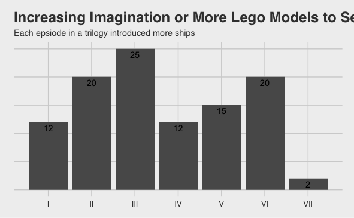

```r
ggplot(episodes, aes(episode, total)) +
  geom_col() +
  geom_text(aes(label = total, y = total -1), color = "black") +
  theme_fivethirtyeight() +   scale_color_fivethirtyeight() +
  labs(
    title = "Increasing Imagination or More Lego Models to Sell?",
    subtitle = "Each epsiode in a trilogy introduced more ships",
    y = ""
  ) +
  scale_y_continuous(labels = NULL) +
  scale_x_continuous(labels = c("I", "II", "III", "IV", "V", "VI", "VII"), breaks = 1:7, minor_breaks = NULL)
```

*Bad data for episode 7?*

Interestingly, it appears that prequels followed a trend in the original 3 movies by introducing more ships over time.

```r
pop_ships <- tibble(
  name = map_chr(ships, "name"),
  films = map_dbl(ships, ~length(.x$films))
)
pop_vehs <- tibble(
  name = map_chr(vehicles, "name"),
  films = map_dbl(vehicles, ~length(.x$films))
)
all <- rbind(pop_ships, pop_vehs)
```

This graph makes it tempting to jump to conclusions, but there are only 76 unique ships! Some of the ships appear in more than one episode. To get a sense for some of the most popular ships, we can count the number of movies per ship:

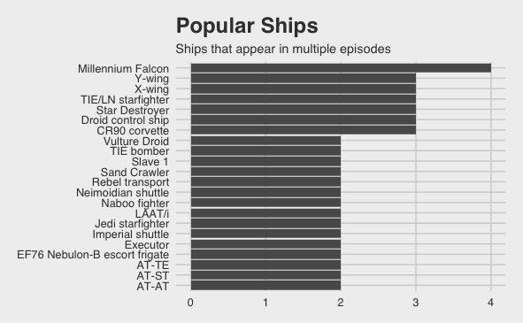

```r
pop_all <- rbind(pop_ships, pop_vehs) %>%
  filter(films > 1)
ggplot(pop_all, aes(reorder(name, films), films)) +
  geom_col() +
  coord_flip() +
  theme_fivethirtyeight() +   scale_color_fivethirtyeight() +
  labs(
    title = "Popular Ships",
    subtitle = "Ships that appear in multiple episodes",
    x = ""
  ) +
  scale_y_continuous(minor_breaks = NULL)
```